# Project

Hsiu Yuan Yang

Fall 2022

## US Storm / Disaster Analysis

Weather data is closely related to our lives. People would check on the current temperature and the raining probability when they go out, and they would monitor the latest storm / atmospheric event information in order to get prepared.

While I come from a country which has a lot of weather disasters, I was curious about what the natural disasters in US are like. I would like to know more about the disaster types, the occurring patterns (if any), etc. Hence, I decided to choose this topic as my R project.

The data sets used in this project are from the Storm Events Database owned by National Centers for Environmental Information - National Oceanic and Atmospheric Administration (NOAA). I will be using several data sets from NOAA, i.e. the storm / event details data sets for 2010 to 2022. The datasets are downloaded from https://www.ncei.noaa.gov/pub/data/swdi/stormevents/csvfiles/, and detailed documentation about the fields / columns can be found on https://www.ncei.noaa.gov/pub/data/swdi/stormevents/csvfiles/Storm-Data-Bulk-csv-Format.pdf.

The NOAA data sets are categorized by year, i.e. each csv file downloaded from its website is only for a specific year. While I planned to use the data set for a whole year cycle, it is noted that the data for the current 2022 cycle is not yet complete (with data only up to June), therefore I have manually created a data set to filter out information from July 2021 to June 2022. Besides, since I would like to compare if there are differences between the past (choosing 10 years before as a target) and the present, I also manually created a data set to filter out information from July 2011 to June 2012. In addition, to do future time series predictions, I also manually consolidated the storm / event data from January 2010 to the latest June 2022.

In short, 3 sets of data are in use for this project:

1. Storm / event details for the current cycle (i.e. Jul 2021 to Jun 2022)
2. Storm / event details for the past cycle (i.e. Jul 2011 to Jun 2012)
3. Storm / event details consolidated (i.e. Jan 2010 to Jun 2022)

Below outlines the details of the storm / event data sets (using the current cycle (i.e. Jul 2021 to Jun 2022) as an example):

```r
# data set for storm / event details of the current cycle (i.e. Jul 2021 to Jun 2022)
storm.current.raw <- read.csv("C:/Users/Yang Hsiu Yuan/Desktop/CMU/2022 Fall semester/94842 Programming R for Analytics/Project/StormEvents_details_current.csv", stringsAsFactors=TRUE)

# data set for storm / event details of the past cycle (i.e. Jul 2011 to Jun 2012)
storm.past.raw <- read.csv("C:/Users/Yang Hsiu Yuan/Desktop/CMU/2022 Fall semester/94842 Programming R for Analytics/Project/StormEvents_details_previous.csv", stringsAsFactors=TRUE)

# data set for storm / event details consolidated (i.e. Jan 2010 to Jun 2022)
storm.consolidated.raw <- read.csv("C:/Users/Yang Hsiu Yuan/Desktop/CMU/2022 Fall semester/94842 Programming R for Analytics/Project/StormEvents_details_consolidated.csv", stringsAsFactors=TRUE)

# illustrate data set (using the current cycle one as an example)
colnames(storm.current.raw)
```

```
##  [1] "BEGIN_YEARMONTH"    "BEGIN_DAY"          "BEGIN_TIME"
##  [4] "END_YEARMONTH"      "END_DAY"            "END_TIME"
##  [7] "EPISODE_ID"         "EVENT_ID"           "STATE"
## [10] "STATE_FIPS"         "YEAR"               "MONTH_NAME"
## [13] "EVENT_TYPE"         "CZ_TYPE"            "CZ_FIPS"
## [16] "CZ_NAME"            "WFO"                "BEGIN_DATE_TIME"
## [19] "CZ_TIMEZONE"        "END_DATE_TIME"      "INJURIES_DIRECT"
## [22] "INJURIES_INDIRECT"  "DEATHS_DIRECT"      "DEATHS_INDIRECT"
## [25] "DAMAGE_PROPERTY"    "DAMAGE_CROPS"       "SOURCE"
## [28] "MAGNITUDE"          "MAGNITUDE_TYPE"     "FLOOD_CAUSE"
## [31] "CATEGORY"           "TOR_F_SCALE"        "TOR_LENGTH"
## [34] "TOR_WIDTH"          "TOR_OTHER_WFO"      "TOR_OTHER_CZ_STATE"
## [37] "TOR_OTHER_CZ_FIPS"  "TOR_OTHER_CZ_NAME"  "BEGIN_RANGE"
## [40] "BEGIN_AZIMUTH"      "BEGIN_LOCATION"     "END_RANGE"
## [43] "END_AZIMUTH"        "END_LOCATION"       "BEGIN_LAT"
## [46] "BEGIN_LON"          "END_LAT"            "END_LON"
## [49] "EPISODE_NARRATIVE"  "EVENT_NARRATIVE"    "DATA_SOURCE"
```

```r
str(storm.current.raw)
```

```
## 'data.frame':    67872 obs. of  51 variables:
##  $ BEGIN_YEARMONTH   : int  202107 202107 202107 202107 202107 202107 202107 202107 202107 202107 ...
##  $ BEGIN_DAY         : int  20 22 30 31 20 31 3 3 3 11 ...
##  $ BEGIN_TIME        : int  2230 1449 1910 1330 2025 1630 2000 100 2136 1602 ...
##  $ END_YEARMONTH     : int  202107 202107 202107 202107 202107 202107 202107 202107 202107 202107 ...
##  $ END_DAY           : int  20 22 30 31 20 31 7 4 4 11 ...
##  $ END_TIME          : int  2230 1449 1910 1330 2025 1630 1131 0 700 1602 ...
##  $ EPISODE_ID        : int  159008 159623 159709 159711 159008 159711 162430 162430 162430 159246 ...
##  $ EVENT_ID          : int  961536 965330 965533 965535 961538 965545 980717 980718 980716 977011 ...
##  $ STATE             : Factor w/ 66 levels "ALABAMA","ALASKA",..: 9 9 9 9 9 9 3 3 3 1 ...
##  $ STATE_FIPS        : int  8 8 8 8 8 8 97 97 97 1 ...
##  $ YEAR              : int  2021 2021 2021 2021 2021 2021 2021 2021 2021 2021 ...
##  $ MONTH_NAME        : Factor w/ 12 levels "April","August",..: 6 6 6 6 6 6 6 6 6 6 ...
##  $ EVENT_TYPE        : Factor w/ 48 levels "Astronomical Low Tide",..: 6 6 6 6 6 6 21 39 21 40 ...
##  $ CZ_TYPE           : Factor w/ 2 levels "C","Z": 1 1 1 1 1 1 2 2 2 1 ...
```

[output cut: 37 more lines]

The data types covered in this set include some dates, event description such as event type, event location, and some event characteristics such as numbers of injuries and deaths.

## Analysis Preparation and Potential Questions in Mind

To start with, considering the data sets used are rather large, and I would only like to focus on the storm / disaster details, I removed the columns that have a majority of NA values and only kept those that I would like to conduct my analysis on.

```r
# create subset for the current cycle
storm.current <- subset(storm.current.raw, select = -c(EPISODE_ID, SOURCE, CATEGORY, TOR_OTHER_WFO:DATA_SOURCE))
storm.current <- storm.current[order(storm.current$BEGIN_YEARMONTH),]

# create subset for the past cycle
storm.past <- subset(storm.past.raw, select = -c(EPISODE_ID, SOURCE, CATEGORY, TOR_OTHER_WFO:DATA_SOURCE))
storm.past <- storm.past[order(storm.past$BEGIN_YEARMONTH),]

# create subset for the consolidated set
storm.consolidated <- subset(storm.consolidated.raw, select = -c(EPISODE_ID, SOURCE, CATEGORY, TOR_OTHER_WFO:DATA_SOURCE))
storm.consolidated <- storm.consolidated[order(storm.consolidated$BEGIN_YEARMONTH),]

# print out the updated column names for the current cycle as an example, the column names are the same for all 3 datasets
colnames(storm.current)
```

```
##  [1] "BEGIN_YEARMONTH"   "BEGIN_DAY"         "BEGIN_TIME"
##  [4] "END_YEARMONTH"     "END_DAY"           "END_TIME"
##  [7] "EVENT_ID"          "STATE"             "STATE_FIPS"
## [10] "YEAR"              "MONTH_NAME"        "EVENT_TYPE"
## [13] "CZ_TYPE"           "CZ_FIPS"           "CZ_NAME"
## [16] "WFO"               "BEGIN_DATE_TIME"   "CZ_TIMEZONE"
## [19] "END_DATE_TIME"     "INJURIES_DIRECT"   "INJURIES_INDIRECT"
## [22] "DEATHS_DIRECT"     "DEATHS_INDIRECT"   "DAMAGE_PROPERTY"
## [25] "DAMAGE_CROPS"      "MAGNITUDE"         "MAGNITUDE_TYPE"
## [28] "FLOOD_CAUSE"       "TOR_F_SCALE"       "TOR_LENGTH"
## [31] "TOR_WIDTH"
```

```r
summary(storm.current)
```

```
##  BEGIN_YEARMONTH    BEGIN_DAY       BEGIN_TIME   END_YEARMONTH
##  Min.   :202107   Min.   : 1.00   Min.   :   0   Min.   :202107
##  1st Qu.:202109   1st Qu.: 7.00   1st Qu.: 700   1st Qu.:202109
##  Median :202201   Median :13.00   Median :1424   Median :202201
##  Mean   :202163   Mean   :14.07   Mean   :1233   Mean   :202163
##  3rd Qu.:202204   3rd Qu.:21.00   3rd Qu.:1800   3rd Qu.:202204
##  Max.   :202206   Max.   :31.00   Max.   :2359   Max.   :202206
##
##     END_DAY         END_TIME       EVENT_ID                STATE
##  Min.   : 1.00   Min.   :   0   Min.   : 957393   TEXAS       : 4425
##  1st Qu.: 9.00   1st Qu.:1117   1st Qu.: 983924   MINNESOTA   : 2990
##  Median :15.00   Median :1620   Median :1002261   SOUTH DAKOTA: 2819
##  Mean   :16.35   Mean   :1488   Mean   :1002237   CALIFORNIA  : 2663
##  3rd Qu.:24.00   3rd Qu.:1918   3rd Qu.:1020215   NEW YORK    : 2561
##  Max.   :31.00   Max.   :2359   Max.   :1044700   KANSAS      : 2403
##                                                   (Other)     :50011
##    STATE_FIPS         YEAR         MONTH_NAME                EVENT_TYPE
##  Min.   : 1.00   Min.   :2021   June    : 8583   Thunderstorm Wind:18957
##  1st Qu.:20.00   1st Qu.:2021   May     : 8304   Hail             : 7306
##  Median :33.00   Median :2022   July    : 7856   High Wind        : 5998
##  Mean   :33.88   Mean   :2022   August  : 7744   Drought          : 5113
##  3rd Qu.:46.00   3rd Qu.:2022   December: 6009   Flash Flood      : 3959
##  Max.   :99.00   Max.   :2022   April   : 5986   Winter Weather   : 3891
##                                 (Other) :23390   (Other)          :22648
##  CZ_TYPE      CZ_FIPS            CZ_NAME           WFO
##  C:36097   Min.   :  1.0   WASHINGTON:  512   LWX    : 2808
##  Z:31775   1st Qu.: 25.0   MONTGOMERY:  472   FSD    : 1776
##            Median : 63.0   JEFFERSON :  408   ALY    : 1361
##            Mean   :107.4   JACKSON   :  398   PHI    : 1332
##            3rd Qu.:123.0   LINCOLN   :  395   OUN    : 1320
##            Max.   :873.0   MADISON   :  379   FGF    : 1281
##                            (Other)   :65308   (Other):57994
##            BEGIN_DATE_TIME   CZ_TIMEZONE               END_DATE_TIME
##  01-JAN-22 00:00:00:  538   CST-6  :29759   31-DEC-21 23:59:00:  476
##  01-APR-22 00:00:00:  524   EST-5  :23821   30-APR-22 23:59:00:  469
##  01-MAR-22 00:00:00:  510   MST-7  : 8871   31-MAY-22 23:59:00:  426
##  01-MAY-22 00:00:00:  490   PST-8  : 4001   31-JAN-22 23:59:00:  412
##  01-AUG-21 00:00:00:  447   HST-10 :  713   31-JUL-21 23:59:00:  412
##  01-JUN-22 00:00:00:  442   AKST-9 :  341   28-FEB-22 23:59:00:  410
##  (Other)           :64921   (Other):  366   (Other)           :65267
```

[output cut: 17 more lines]

```
##                              :61626      :66031   Min.   : 0.01
##  Heavy Rain                  : 5836   EF0:  673   1st Qu.: 0.68
##  Heavy Rain / Burn Area      :  169   EF1:  728   Median : 2.16
##  Heavy Rain / Tropical System:  142   EF2:  189   Mean   : 3.63
##  Heavy Rain / Snow Melt      :   63   EF3:   37   3rd Qu.: 4.97
##  Ice Jam                     :   29   EF4:   10   Max.   :33.97
##  (Other)                     :    7   EFU:  204   NA's   :66031
##    TOR_WIDTH
##  Min.   :   1
##  1st Qu.:  50
##  Median : 100
##  Mean   : 183
##  3rd Qu.: 200
##  Max.   :2600
##  NA's   :66031
```

```r
head(storm.current)
```

```
##   BEGIN_YEARMONTH BEGIN_DAY BEGIN_TIME END_YEARMONTH END_DAY END_TIME EVENT_ID
## 1          202107        20       2230        202107      20     2230   961536
## 2          202107        22       1449        202107      22     1449   965330
## 3          202107        30       1910        202107      30     1910   965533
## 4          202107        31       1330        202107      31     1330   965535
## 5          202107        20       2025        202107      20     2025   961538
## 6          202107        31       1630        202107      31     1630   965545
##      STATE STATE_FIPS YEAR MONTH_NAME  EVENT_TYPE CZ_TYPE CZ_FIPS    CZ_NAME
## 1 COLORADO          8 2021       July Debris Flow       C      97     PITKIN
## 2 COLORADO          8 2021       July Debris Flow       C      37      EAGLE
## 3 COLORADO          8 2021       July Debris Flow       C      91      OURAY
## 4 COLORADO          8 2021       July Debris Flow       C     113 SAN MIGUEL
## 5 COLORADO          8 2021       July Debris Flow       C      45   GARFIELD
## 6 COLORADO          8 2021       July Debris Flow       C      45   GARFIELD
##   WFO    BEGIN_DATE_TIME CZ_TIMEZONE      END_DATE_TIME INJURIES_DIRECT
```

[output cut: 27 more lines]

Before starting the analysis, install the libraries / packages that will be used.

```r
# install libraries
install.packages("tidyverse")
install.packages("plyr")
install.packages("usmap")
install.packages("caret")
```

Below is a list of questions I would like to examine throughout this project:

I.Exploratory Data Analysis for the Current Cycle:

- Which type(s) of event occur the most often?
- Is there a specific month / season when more events happen? Throughout the year, how does the event occurrence fluctuate through time?
- Which state(s) have potentially more events compared to other states?
- For the states that occur more events than others, what are the most frequent events?
- Were there high injuries and deaths for the events?
- Is there a relationship between the length and the width of tornadoes?

II.Comparison of the Current Cycle and the Past Cycle:

- Are the top 5 events that occur the most in the current cycle same as these in the past?
- Are there any differences of the time fluctuation of event occurrence?
- Has the wind speed changed throughout the years?
- Has the hail size changed throughout the years?

III.Prediction using Long Term Time Series Data:

- Can we predict the tornado width with tornado length for the next 20 tornadoes using previous collected data?

## I. Exploratory Data Analysis for the Current Cycle

##### Q1a: Which type(s) of event occur the most often?

Before starting the analysis, understand what the potential types / option for event type are.Relevant libraries should also be loaded.

```r
unique(storm.current$EVENT_TYPE)
```

```
##  [1] Debris Flow                High Surf
##  [3] Strong Wind                Thunderstorm Wind
##  [5] Hail                       Wildfire
##  [7] Heat                       Drought
##  [9] Funnel Cloud               Flash Flood
## [11] Lightning                  Marine Thunderstorm Wind
## [13] Heavy Rain                 Flood
## [15] Dust Storm                 High Wind
## [17] Tropical Storm             Waterspout
## [19] Rip Current                Tornado
## [21] Marine Tropical Storm      Tropical Depression
## [23] Excessive Heat             Marine Hail
## [25] Coastal Flood              Storm Surge/Tide
## [27] Marine Tropical Depression Marine High Wind
## [29] Marine Strong Wind         Dense Fog
## [31] Astronomical Low Tide      Hurricane
## [33] Marine Hurricane/Typhoon   Marine Dense Fog
## [35] Frost/Freeze               Avalanche
## [37] Winter Weather             Lakeshore Flood
## [39] Heavy Snow                 Winter Storm
## [41] Blizzard                   Lake-Effect Snow
## [43] Cold/Wind Chill            Extreme Cold/Wind Chill
## [45] Ice Storm                  Tsunami
## [47] Sleet                      Dust Devil
## 48 Levels: Astronomical Low Tide Avalanche Blizzard ... Winter Weather
```

```r
library(plyr)
library(tidyverse)
```

A barplot is illustrated below to examine the occurrence of each event type.

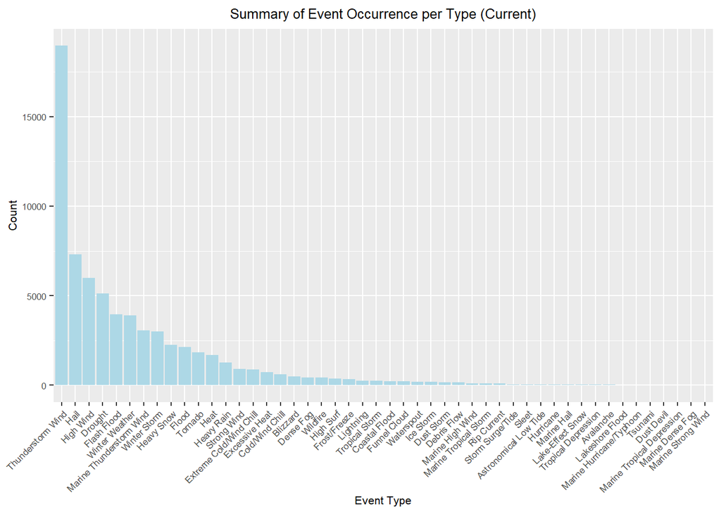

```r
# plot number of events occurred per type
event.plot <- ggplot(data = storm.current, aes(x = fct_infreq(EVENT_TYPE)))
event.plot + geom_bar(fill = 'lightblue') + xlab("Event Type") + ylab("Count") + ggtitle("Summary of Event Occurrence per Type (Current)") + theme(text = element_text(size=8),
        axis.text.x = element_text(angle=45, hjust=1), plot.title = element_text(hjust = 0.5))
```

```r
# a closer look on the top 5 event types
table(storm.current$EVENT_TYPE)
```

```
##
##      Astronomical Low Tide                  Avalanche
##                         38                         26
##                   Blizzard              Coastal Flood
##                        484                        216
##            Cold/Wind Chill                Debris Flow
##                        612                        146
##                  Dense Fog                    Drought
##                        428                       5113
##                 Dust Devil                 Dust Storm
##                          8                        168
##             Excessive Heat    Extreme Cold/Wind Chill
##                        714                        865
##                Flash Flood                      Flood
##                       3959                       2141
##               Frost/Freeze               Funnel Cloud
##                        338                        213
##                       Hail                       Heat
##                       7306                       1688
##                 Heavy Rain                 Heavy Snow
##                       1265                       2241
##                  High Surf                  High Wind
##                        370                       5998
##                  Hurricane                  Ice Storm
##                         38                        177
##           Lake-Effect Snow            Lakeshore Flood
##                         31                         12
##                  Lightning           Marine Dense Fog
##                        253                          3
##                Marine Hail           Marine High Wind
##                         32                        102
##   Marine Hurricane/Typhoon         Marine Strong Wind
##                         12                          2
##   Marine Thunderstorm Wind Marine Tropical Depression
##                       3061                          8
##      Marine Tropical Storm                Rip Current
##                         97                         93
##                      Sleet           Storm Surge/Tide
##                         42                         50
##                Strong Wind          Thunderstorm Wind
##                        920                      18957
##                    Tornado        Tropical Depression
##                       1841                         28
##             Tropical Storm                    Tsunami
##                        253                          9
##                 Waterspout                   Wildfire
##                        202                        427
##               Winter Storm             Winter Weather
##                       2994                       3891
```

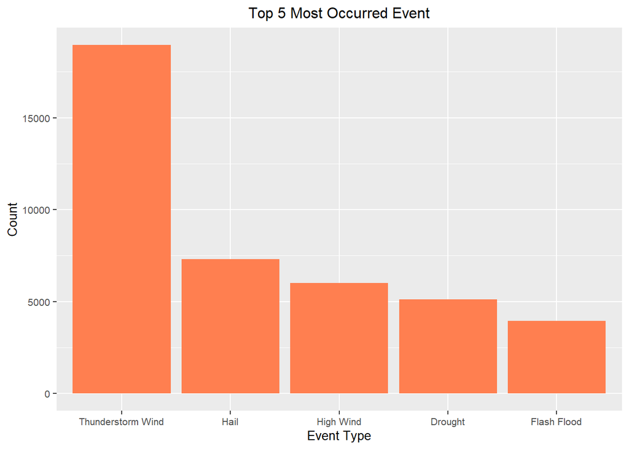

```r
# the top 5 most occurred events are Thunderstorm Wind, Hail, High Wind, Drought, Flash Flood
top5event <- c('Thunderstorm Wind', 'Hail', 'High Wind', 'Drought', 'Flash Flood')

top5event.plot <- ggplot(data = storm.current[storm.current$EVENT_TYPE %in% top5event,], aes(x = fct_infreq(EVENT_TYPE)))
top5event.plot + geom_bar(fill = 'coral') + ylab("Count") + xlab("Event Type") + ggtitle("Top 5 Most Occurred Event") + theme(text = element_text(size=10),
        axis.text.x = element_text(angle=0), plot.title = element_text(hjust = 0.5))
```

From the barplot above, it is noted that during the current cycle, thunderstorm wind occurs the most often, following by hail, high wind, drought, and flash flood. It is also noted that thunderstorm wind occurs more than twice of the number of hails.

##### Q1b: Is there a specific month / season when more events happen? Throughout the year, how does the event occurrence fluctuate through time?

A barplot is illustrated below to examine the occurrence of events throughout the year.

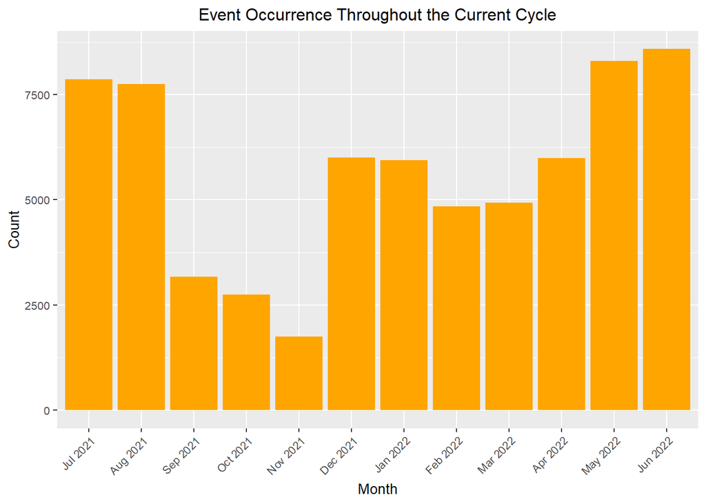

```r
# plot of event occurrence throughout the current cycle
month.order <- c('July', 'August', 'September', 'October', 'November', 'December', 'January', 'February', 'March', 'April', 'May', 'June')
month.labels <- c('Jul 2021', 'Aug 2021', ' Sep 2021', 'Oct 2021', 'Nov 2021', 'Dec 2021', 'Jan 2022', 'Feb 2022', 'Mar 2022', 'Apr 2022', 'May 2022', 'Jun 2022')
month.plot <- ggplot(data = storm.current, aes(x = MONTH_NAME))
month.plot + geom_bar(fill = 'orange') + xlab("Month") + ylab("Count") + ggtitle("Event Occurrence Throughout the Current Cycle") + theme(text = element_text(size=10), axis.text.x = element_text(angle=45, hjust=1), plot.title = element_text(hjust = 0.5)) + scale_x_discrete(limits = month.order, labels = month.labels)
```

From the barplot above, it is noted that throughout the current cycle, it is more likely to have more events during summer. For the current cycle, June 2022 has occurred the most events, and November 2021 has occurred the least events.

Let’s also view the differences between each season. Following meteorological seasons, divide the months into the seasons as the following:

- Spring: March, April, May
- Summer: June, July, August
- Fall: September, October, November
- Winter: December, January, February

A barplot is illustrated below to examine the occurrence of events for each season.

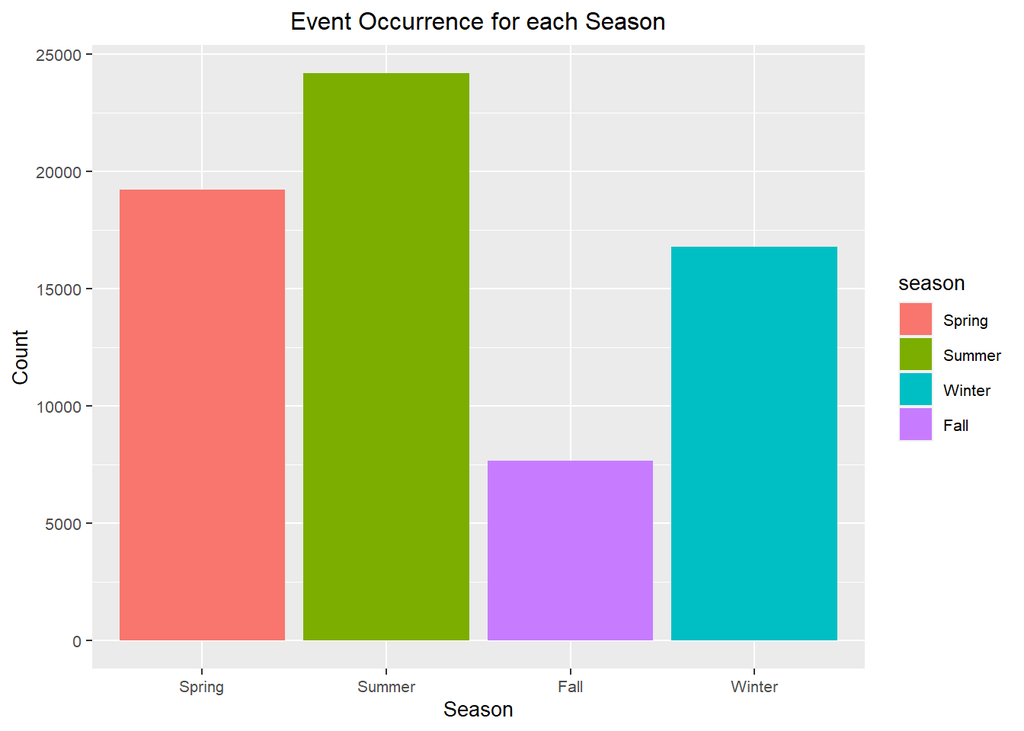

```r
# assign months to each season category
storm.current.season <- mutate(storm.current,
                                  season = as.factor(plyr::mapvalues(MONTH_NAME, c('July', 'August', 'September', 'October', 'November', 'December', 'January', 'February', 'March', 'April', 'May', 'June'), c('Summer', 'Summer', 'Fall', 'Fall', 'Fall', 'Winter', 'Winter', 'Winter', 'Spring', 'Spring', 'Spring', 'Summer'))))

# draw the barplot for each season
season.order <- c('Spring', 'Summer', 'Fall', 'Winter')
season.plot <- ggplot(data = storm.current.season, aes(x = season, fill = season))
season.plot + geom_bar() + xlab("Season") + ylab("Count") + ggtitle("Event Occurrence for each Season") + theme(text = element_text(size=10), plot.title = element_text(hjust = 0.5)) + scale_x_discrete(limits = season.order, labels = season.order)
```

From the barplot above, it shows clearly that summer is the season which occurs the most events. Whereas the number of events in spring and winter are similar, and fall is the season which has the least events.

##### Q1c: Which state(s) have potentially more events compared to other states?

While there are 50 states and 3243 counties in US, I was also curious on which states were more prone to these natural disasters.The current dataset in use has in fact more than 50 values on its STATE column; this is because areas such as E Pacific, GULF OF MEXICO, LAKE HURON, etc. were also included.

```r
# generate the count of events per state
state.event.summary <- storm.current %>%
  group_by(STATE) %>%
  dplyr::summarize(n = n()) %>%
  arrange(., desc(n))
colnames(state.event.summary) <- c("STATE", "Count")
knitr::kable(state.event.summary, caption = "Count of Events per State")
```

Count of Events per State

| STATE | Count |
| --- | --- |
| TEXAS | 4425 |
| MINNESOTA | 2990 |
| SOUTH DAKOTA | 2819 |
| CALIFORNIA | 2663 |
| NEW YORK | 2561 |
| KANSAS | 2403 |
| VIRGINIA | 2330 |
| PENNSYLVANIA | 2165 |
| NEBRASKA | 1946 |
| COLORADO | 1823 |
| OKLAHOMA | 1805 |
| IOWA | 1788 |
| ILLINOIS | 1779 |
| KENTUCKY | 1746 |
| MISSOURI | 1587 |
| NORTH CAROLINA | 1489 |
| NORTH DAKOTA | 1466 |
| MONTANA | 1446 |
| WISCONSIN | 1431 |
| OHIO | 1419 |
| TENNESSEE | 1335 |
| NEW MEXICO | 1308 |
| GULF OF MEXICO | 1237 |
| ARKANSAS | 1223 |
| ATLANTIC NORTH | 1157 |
| GEORGIA | 1103 |
| MICHIGAN | 1056 |
| ARIZONA | 1052 |
| FLORIDA | 1043 |
| INDIANA | 1026 |
| SOUTH CAROLINA | 1025 |
| WYOMING | 1005 |
| ALABAMA | 988 |
| MARYLAND | 981 |
| MISSISSIPPI | 975 |
| WEST VIRGINIA | 958 |
| NEW JERSEY | 855 |
| HAWAII | 713 |
| LOUISIANA | 705 |
| UTAH | 626 |
| ATLANTIC SOUTH | 579 |
| MASSACHUSETTS | 579 |
| NEVADA | 576 |
| IDAHO | 419 |
| VERMONT | 399 |
| MAINE | 346 |
| OREGON | 345 |
| ALASKA | 341 |
| WASHINGTON | 333 |
| CONNECTICUT | 280 |
| NEW HAMPSHIRE | 233 |
| LAKE MICHIGAN | 189 |
| PUERTO RICO | 183 |
| LAKE SUPERIOR | 129 |
| LAKE ERIE | 108 |
| DELAWARE | 85 |
| RHODE ISLAND | 80 |
| LAKE HURON | 55 |
| DISTRICT OF COLUMBIA | 49 |
| LAKE ST CLAIR | 40 |
| AMERICAN SAMOA | 23 |
| LAKE ONTARIO | 17 |
| GUAM | 16 |
| VIRGIN ISLANDS | 8 |
| ST LAWRENCE R | 5 |
| E PACIFIC | 3 |

From the above table, it is noted that Texas, Minnesota, South Dakota, California and New York are the top 5 states with the most events during the current cycle. While there is a lot of information in this table, for the reader’s easier view, a US map is also created as below:

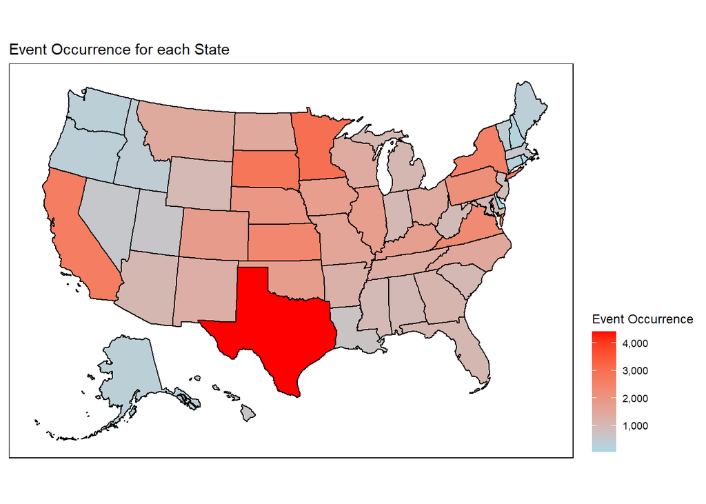

```r
library(usmap)

# add a state column for usmap
state.event.map <- mutate(state.event.summary,
                        state = STATE)
plot_usmap(data = state.event.map, value = 'Count', labels = FALSE) +
  scale_fill_continuous(low = 'lightblue', high = 'red',
                        name = 'Event Occurrence', label = scales::comma) +
  theme(legend.position = 'right') +
  theme(panel.background = element_rect(color = 'black')) +
  labs(title = 'Event Occurrence for each State')
```

From the above US map, it is very clear that Texas, with the largest event occurrence frequency, stands out of the other states. The east and north part of US also has larger event occurrences compared to the states on the west side (excluding california).

##### Q1d: For the states that occur more events than others, what are the most frequent events?

Now that knowing which states have higher event occurrences, I was also curious about their corresponding top event types. The following identifies the top event types occurring in Texas, Minnesota, South Dakota, California, and New York.

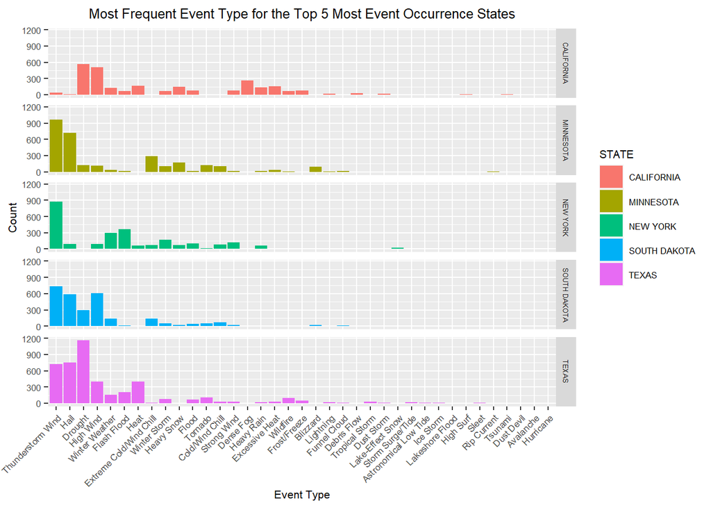

```r
top5states <- c('TEXAS', 'MINNESOTA', 'SOUTH DAKOTA', 'CALIFORNIA', 'NEW YORK')

# plot top events for the 5 states
top5states.plot <- ggplot(data = storm.current[storm.current$STATE %in% top5states,], aes(x = fct_infreq(EVENT_TYPE), fill = STATE))

top5states.plot + geom_bar() + xlab("Event Type") + ylab("Count") + facet_grid(STATE~.) + ggtitle("Most Frequent Event Type for the Top 5 Most Event Occurrence States") + theme(strip.text = element_text(size = 5), text = element_text(size=8),
        axis.text.x = element_text(angle=45, hjust=1),  plot.title = element_text(hjust = 0.5))
```

##### Q1e: Were there high injuries and deaths for the events?

Assuming there is a positive relationship between injury / death amount and the frequency of the events, I would like to plot a violin plot for the top 5 event types identified in 1a (i.e. ‘Thunderstorm Wind’, ‘Hail’, ‘High Wind’, ‘Drought’, ‘Flash Flood’.

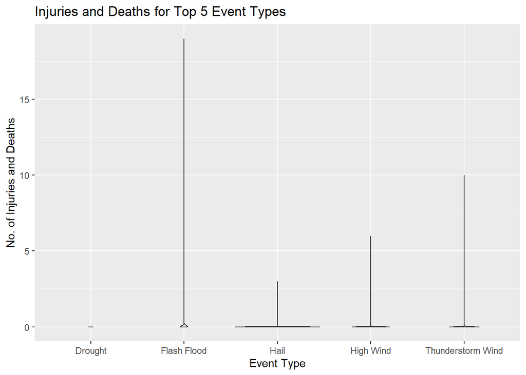

```r
top5event <- c('Thunderstorm Wind', 'Hail', 'High Wind', 'Drought', 'Flash Flood')

# aggregate injury and death data
storm.current.injuries <- mutate(storm.current,
                        INJURY_DEATH = INJURIES_DIRECT + INJURIES_INDIRECT + DEATHS_DIRECT + DEATHS_INDIRECT)
storm.current.injuries <- filter(storm.current.injuries, EVENT_TYPE %in% top5event)

storm.current.injuries.plot <- ggplot(storm.current.injuries, aes(x = EVENT_TYPE, y = INJURY_DEATH))
storm.current.injuries.plot + geom_violin() + xlab("Event Type") + ylab("No. of Injuries and Deaths") + ggtitle("Injuries and Deaths for Top 5 Event Types")
```

From the above violin plot, it is noted that actually the injuries and deaths rate for the top 5 events are mostly zero. For this current cycle, drought has not led to any injuries and deaths. However, it is also noticed that there are several injuries and deaths for flash flood, with the largest number of injuries and deaths per event around 18.

##### Q1f: Is there a relationship between the length and the width of tornadoes?

While tornadoes are very common in US, I was curious if a longer tornado always has a wider width. Understood that tornadoes may have different shapes and sizes, I decided to do an examination of the correlation between the length and the width of tornadoes.

Since the dataset uses miles for length and feet for width, I decided to transform the unit of width into miles by dividing it with 5280 to make easier interpretation and get clearer plots. Before directly drawing the linear model plot, I also decided to conduct a t-test to inspect the relationship between tornado length and width.

```r
# add TOR_WIDTH2 to transform the unit of width into miles
storm.current <- mutate(storm.current,
                        TOR_WIDTH2 = TOR_WIDTH / 5280)

# conduct a t-test on TOR_LENGTH and TOR_WIDTH2 first
t.test(x = storm.current$TOR_WIDTH2, y = storm.current$TOR_LENGTH)
```

```
##
##  Welch Two Sample t-test
##
## data:  storm.current$TOR_WIDTH2 and storm.current$TOR_LENGTH
## t = -35.688, df = 1840.6, p-value < 2.2e-16
## alternative hypothesis: true difference in means is not equal to 0
## 95 percent confidence interval:
##  -3.792876 -3.397716
## sample estimates:
##  mean of x  mean of y
## 0.03466595 3.62996198
```

```r
# construct a linear model using TOR_LENGTH and TOR_WIDTH of the dataset
torn.lmfit <-lm(TOR_LENGTH ~ TOR_WIDTH2, data = storm.current)
summary(torn.lmfit)
```

```
##
## Call:
## lm(formula = TOR_LENGTH ~ TOR_WIDTH2, data = storm.current)
##
## Residuals:
##     Min      1Q  Median      3Q     Max
## -12.241  -2.248  -1.195   1.228  25.232
##
## Coefficients:
##             Estimate Std. Error t value Pr(>|t|)
## (Intercept)   2.2885     0.1046   21.89   <2e-16 ***
## TOR_WIDTH2   38.6971     1.6252   23.81   <2e-16 ***
## ---
## Signif. codes:  0 '***' 0.001 '**' 0.01 '*' 0.05 '.' 0.1 ' ' 1
##
## Residual standard error: 3.78 on 1839 degrees of freedom
##   (66031 observations deleted due to missingness)
## Multiple R-squared:  0.2357, Adjusted R-squared:  0.2352
## F-statistic:   567 on 1 and 1839 DF,  p-value: < 2.2e-16
```

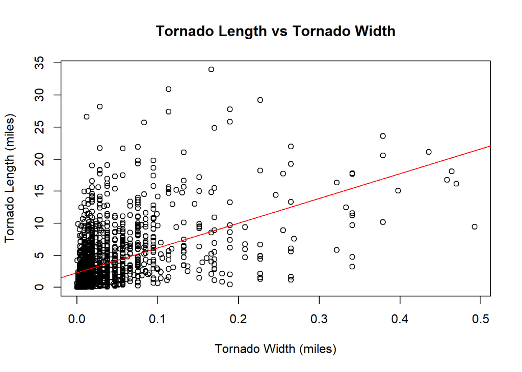

```r
plot(storm.current$TOR_LENGTH ~ storm.current$TOR_WIDTH2,
     ylab = "Tornado Length (miles)",
     xlab = "Tornado Width (miles)",
     main = "Tornado Length vs Tornado Width")
abline(torn.lmfit, col = 'red')
```

From the regression statistics, it is likely that tornado width does have some impact on the tornado length as the p-value of the x variable (i.e. tornado width) is very small. However, it is also noted from the low R-squared value that the model does not fit well. Hence, by viewing at the plot and considering the very low R-squared value, I would not be able to state that there is a linear relationship between the tornado width and length.

More graphs regarding the linear model of tornado width and length are generated below:

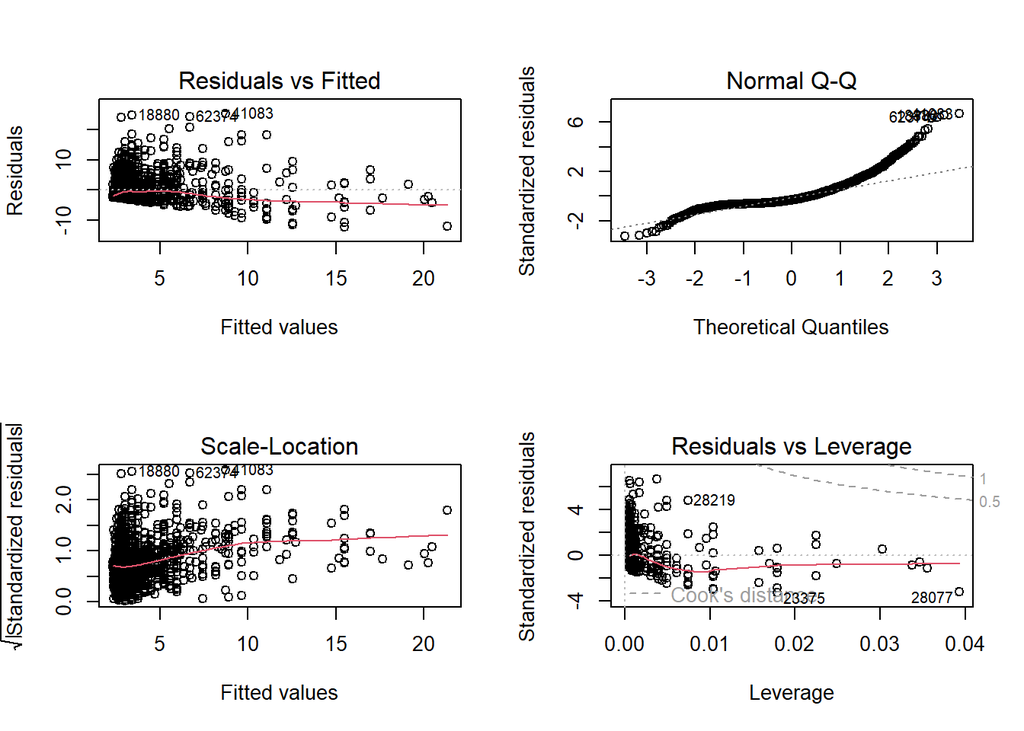

```r
par(mfrow = c(2, 2))
plot(torn.lmfit)
```

It is clear that there is a large difference between the residuals and the fitted line. This further supports a poor to no linear correlation.

```r
# conduct a t-test on TOR_LENGTH and TOR_WIDTH2 first
t.test(x = sqrt(storm.current$TOR_WIDTH2), y = storm.current$TOR_LENGTH)
```

```
##
##  Welch Two Sample t-test
##
## data:  sqrt(storm.current$TOR_WIDTH2) and storm.current$TOR_LENGTH
## t = -34.469, df = 1842, p-value < 2.2e-16
## alternative hypothesis: true difference in means is not equal to 0
## 95 percent confidence interval:
##  -3.670718 -3.275483
## sample estimates:
## mean of x mean of y
## 0.1568612 3.6299620
```

```r
# construct a linear model using TOR_LENGTH and square(TOR_WIDTH) of the dataset
ttorn.lmfit <-lm(TOR_LENGTH ~ sqrt(TOR_WIDTH2), data = storm.current)
summary(ttorn.lmfit)
```

```
##
## Call:
## lm(formula = TOR_LENGTH ~ sqrt(TOR_WIDTH2), data = storm.current)
##
## Residuals:
##      Min       1Q   Median       3Q      Max
## -10.5961  -1.9764  -0.9582   1.1411  24.6139
##
## Coefficients:
##                  Estimate Std. Error t value Pr(>|t|)
## (Intercept)       0.05696    0.15876   0.359     0.72
## sqrt(TOR_WIDTH2) 22.77813    0.85267  26.714   <2e-16 ***
## ---
## Signif. codes:  0 '***' 0.001 '**' 0.01 '*' 0.05 '.' 0.1 ' ' 1
##
## Residual standard error: 3.67 on 1839 degrees of freedom
##   (66031 observations deleted due to missingness)
## Multiple R-squared:  0.2796, Adjusted R-squared:  0.2792
## F-statistic: 713.6 on 1 and 1839 DF,  p-value: < 2.2e-16
```

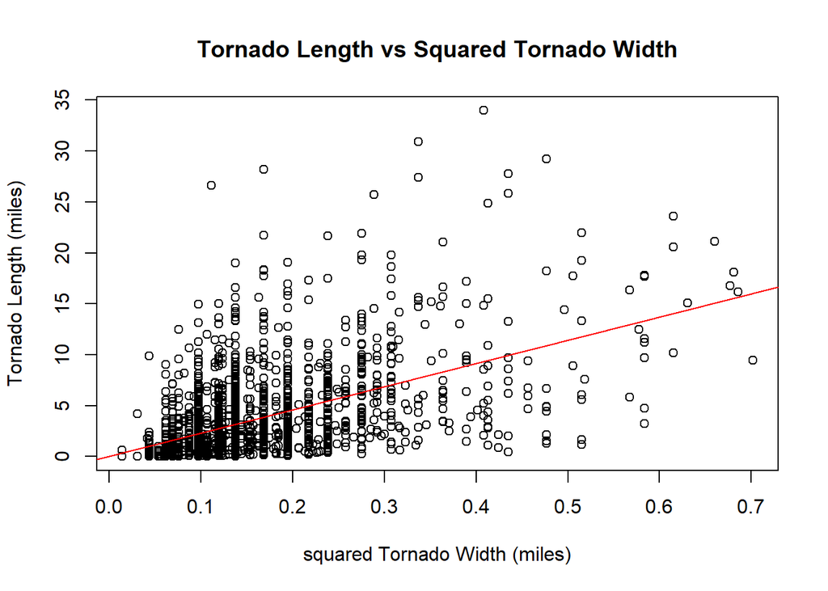

```r
plot(storm.current$TOR_LENGTH ~ sqrt(storm.current$TOR_WIDTH2),
     ylab = "Tornado Length (miles)",
     xlab = "squared Tornado Width (miles)",
     main = "Tornado Length vs Squared Tornado Width")
abline(ttorn.lmfit, col = 'red')
```

More graphs regarding the linear model of squared tornado width and length are generated below:

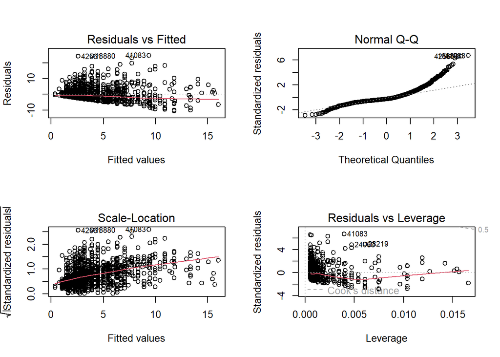

```r
par(mfrow = c(2, 2))
plot(ttorn.lmfit)
```

The 4 residual plots also look very similar like the previous result. It shows that taking square on tornado width does not really improve the model.

## II. Comparison of the current cycle and the past cycle

##### Q2a: Are the top 5 events that occur the most in the current cycle same as these in the past?

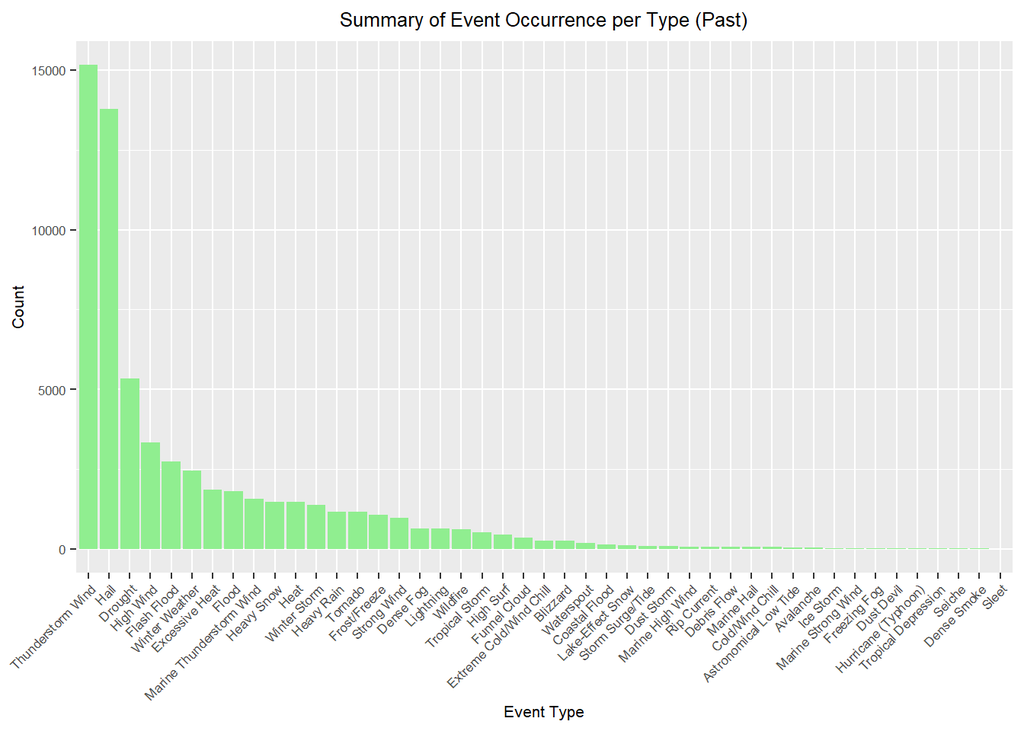

```r
past.event.plot <- ggplot(data = storm.past, aes(x = fct_infreq(EVENT_TYPE)))
past.event.plot + geom_bar(fill = 'lightgreen') + xlab("Event Type") + ylab("Count") + ggtitle("Summary of Event Occurrence per Type (Past)") + theme(text = element_text(size=8),
        axis.text.x = element_text(angle=45, hjust=1), plot.title = element_text(hjust = 0.5))
```

```r
# a closer look on the top 5 event types
table(storm.past$EVENT_TYPE)
```

```
##
##    Astronomical Low Tide                Avalanche                 Blizzard
##                       33                       31                      259
##            Coastal Flood          Cold/Wind Chill              Debris Flow
##                      135                       54                       61
##                Dense Fog              Dense Smoke                  Drought
##                      630                        4                     5344
##               Dust Devil               Dust Storm           Excessive Heat
##                       13                       82                     1861
##  Extreme Cold/Wind Chill              Flash Flood                    Flood
##                      260                     2729                     1807
##             Freezing Fog             Frost/Freeze             Funnel Cloud
##                       18                     1055                      341
##                     Hail                     Heat               Heavy Rain
##                    13793                     1463                     1168
##               Heavy Snow                High Surf                High Wind
##                     1482                      436                     3336
##      Hurricane (Typhoon)                Ice Storm         Lake-Effect Snow
##                       13                       24                      108
##                Lightning              Marine Hail         Marine High Wind
##                      629                       57                       70
##       Marine Strong Wind Marine Thunderstorm Wind              Rip Current
##                       20                     1559                       64
##                   Seiche                    Sleet         Storm Surge/Tide
##                        9                        1                       98
##              Strong Wind        Thunderstorm Wind                  Tornado
##                      972                    15155                     1161
##      Tropical Depression           Tropical Storm               Waterspout
##                       10                      528                      177
##                 Wildfire             Winter Storm           Winter Weather
##                      603                     1386                     2446
```

Compared to the current cycle, whose top 5 event types are Thunderstorm Wind, Hail, High Wind, Drought, Flash Flood, the past cycle actually has the same top 5 events as it. The only difference is just the order of these 5 event types. For the past cycle, the order was Thunderstorm Wind, Hail, Drought, High Wind, Flash Flood, where the order of Drought and High Wind has swapped in the current cycle.

Let’s also do a comparison of the frequency of these 5 top events between the past cycle and the current cycle.

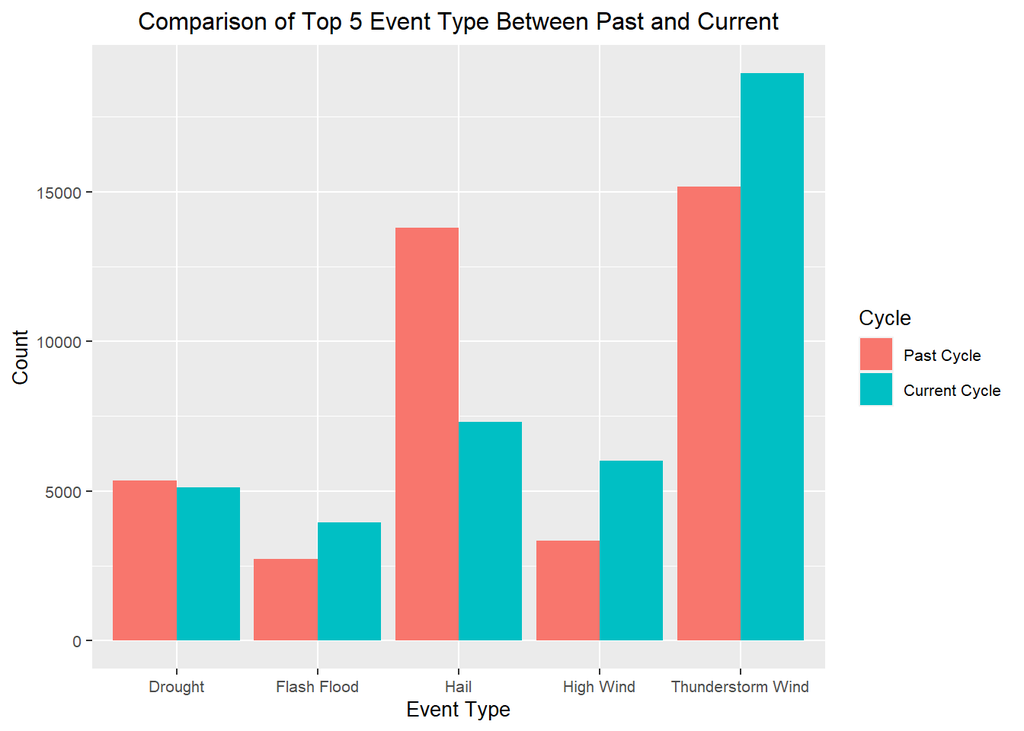

```r
# bind the current dataset and past dataset into a large data frame
total.raw <- rbind(storm.current.raw, storm.past.raw)
total <- subset(total.raw, select = -c(EPISODE_ID, SOURCE, CATEGORY, TOR_OTHER_WFO:DATA_SOURCE))

# for past cycle, cycle is 0; for current cycle, cycle is 1
total <- mutate(total.raw, cycle = as.factor(plyr::mapvalues(YEAR, c(2011, 2012, 2021, 2022), c('Past Cycle', 'Past Cycle', 'Current Cycle', 'Current Cycle'))))

# top 5 event comparison
top5event <- c('Thunderstorm Wind', 'Hail', 'High Wind', 'Drought', 'Flash Flood')

cp.top5event.plot <- ggplot(data = total[total$EVENT_TYPE %in% top5event,], aes(x = EVENT_TYPE, fill = forcats::fct_rev(cycle)))
cp.top5event.plot + geom_bar(position="dodge") + xlab("Event Type") + ylab("Count") + ggtitle("Comparison of Top 5 Event Type Between Past and Current") + theme(text = element_text(size=10),
        axis.text.x = element_text(angle=0), plot.title = element_text(hjust = 0.5)) + guides(fill = guide_legend(title = "Cycle"))
```

From the above comparison plot, it is noted that although the top 5 events remain the same for the current cycle compared to the past cycle, the frequency distribution of the events has changed. In short, there were more thunderstorm winds, high winds, and flash floods in this cycle, while the past cycle occurred more droughts and hails. Hail has largely decreased in the current cycle, which could be related to climate change.

##### Q2b: Are there any differences of the time fluctuation of event occurrence?

After comparing the event type difference, I would also like to look at whether the past cycle and the current cycle has similar time patterns. From 1b, the result shows that in the current cycle, June 2022 has occurred the most events, and November 2021 has occurred the least events. To do a comparison, a barplot is illustrated below to examine the occurrence of events through out the past cycle.

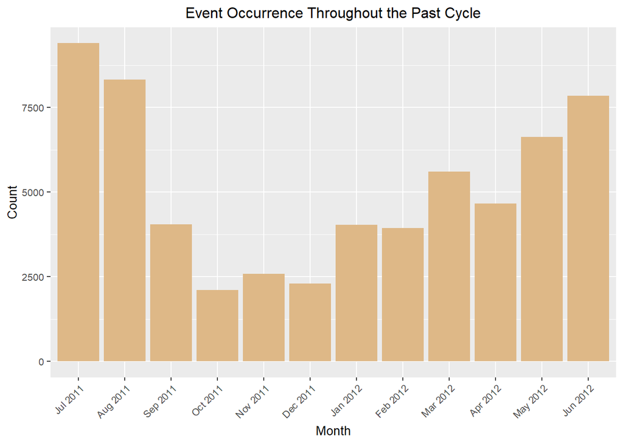

```r
# plot of event occurrence throughout the past cycle
month.order <- c('July', 'August', 'September', 'October', 'November', 'December', 'January', 'February', 'March', 'April', 'May', 'June')
month.labels <- c('Jul 2011', 'Aug 2011', ' Sep 2011', 'Oct 2011', 'Nov 2011', 'Dec 2011', 'Jan 2012', 'Feb 2012', 'Mar 2012', 'Apr 2012', 'May 2012', 'Jun 2012')
month.plot <- ggplot(data = storm.past, aes(x = MONTH_NAME))
month.plot + geom_bar(fill = 'burlywood') + xlab("Month") + ylab("Count") + ggtitle("Event Occurrence Throughout the Past Cycle") + theme(text = element_text(size=10), axis.text.x = element_text(angle=45, hjust=1), plot.title = element_text(hjust = 0.5)) + scale_x_discrete(limits = month.order, labels = month.labels)
```

Compared to 1b, it is noted that the barplot for the past cycle actually has a similar pattern like the current cycle. It is also more likely to have events during summer. For the past cycle, July 2011 has occurred the most events, and October 2011 has occurred the least events.

Similar as above, a comparison of event occurrence throughout the year for the past and current cycle is provided below.

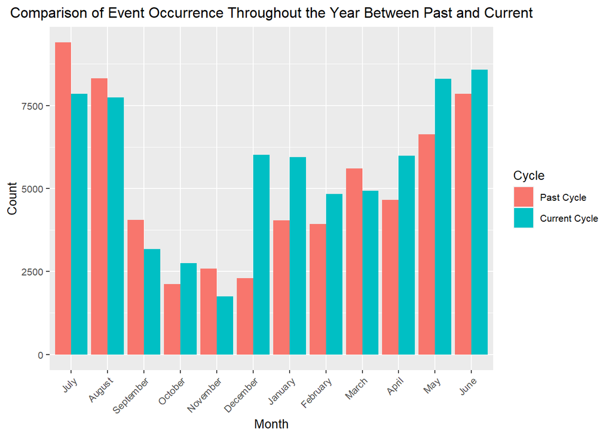

```r
# use the bound total dataset from above
# for past cycle, cycle is 0; for current cycle, cycle is 1

# event occurrence comparison
month.order <- c('July', 'August', 'September', 'October', 'November', 'December', 'January', 'February', 'March', 'April', 'May', 'June')

cp.month.plot <- ggplot(data = total, aes(x = MONTH_NAME, fill = forcats::fct_rev(cycle)))
cp.month.plot + geom_bar(position="dodge") + xlab("Month") + ylab("Count") + ggtitle("Comparison of Event Occurrence Throughout the Year Between Past and Current") + theme(text = element_text(size=10), axis.text.x = element_text(angle=45, hjust=1), plot.title = element_text(hjust = 0.5)) + scale_x_discrete(limits = month.order, labels = month.order) + guides(fill = guide_legend(title = "Cycle"))
```

From the above figure, it is noted that there are no significant differences of event occurrence between the current cycle and the past cycle. However, it is noted that the past cycle has a higher maximum occurrence (i.e. in July) than that of the current cycle. In contrast, the current cycle has a smaller minimum occurrence (i.e. in November) compared to that of the past cycle. The largest difference of the months occurred in December, where the current cycle has around twice occurrences than the past cycle. In addition, the number of months having a higher occurrence than the other cycle is actually quite equal, with the current cycle having 7 months more occurrence than the past one (i.e. October, December, January, February, April, May, June), and the past cycle having 5 months more occurrence than the current one (i.e. July, August, September, November, March).

To take a closer look, below is a barplot for comparison of the occurrence of events for each season in the past cycle.

[figure not shown]

```r
# assign months to each season category
storm.past.season <- mutate(storm.past,
                                  season = as.factor(plyr::mapvalues(MONTH_NAME, c('July', 'August', 'September', 'October', 'November', 'December', 'January', 'February', 'March', 'April', 'May', 'June'), c('Summer', 'Summer', 'Fall', 'Fall', 'Fall', 'Winter', 'Winter', 'Winter', 'Spring', 'Spring', 'Spring', 'Summer'))))

# draw the barplot for each season
season.order <- c('Spring', 'Summer', 'Fall', 'Winter')
season.plot <- ggplot(data = storm.past.season, aes(x = season, fill = season))
season.plot + geom_bar() + xlab("Season") + ylab("Count") + ggtitle("Event Occurrence for each Season of the Past Cycle") + theme(text = element_text(size=10), plot.title = element_text(hjust = 0.5)) + guides(fill = guide_legend(title = "Season") + scale_x_discrete(limits = season.order, labels = season.order))
```

Same as the current cycle, it is noted that summer is the season which occurs the most events and fall is the season with the least events in the past cycle as well. A slight difference would be the past cycle still has a higher occurrence in spring than fall and winter.

A comparison plot of event occurrence for each season is illustrated below.

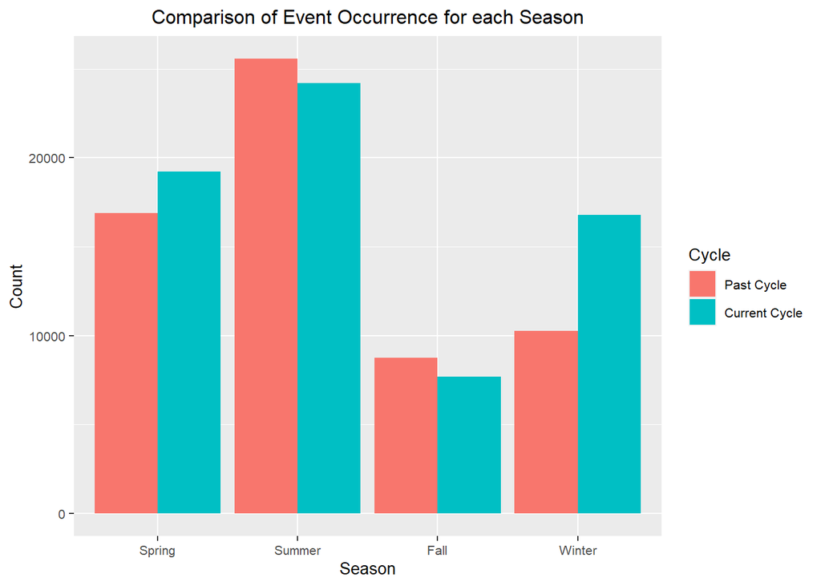

```r
# bind the current season dataset and past season dataset into a large data frame
total.season.raw <- rbind(storm.current.season, storm.past.season)

# for past cycle, cycle is 0; for current cycle, cycle is 1
total.season <- mutate(total.season.raw,
                       season = as.factor(plyr::mapvalues(MONTH_NAME, c('July', 'August', 'September', 'October', 'November', 'December', 'January', 'February', 'March', 'April', 'May', 'June'), c('Summer', 'Summer', 'Fall', 'Fall', 'Fall', 'Winter', 'Winter', 'Winter', 'Spring', 'Spring', 'Spring', 'Summer'))),
                       cycle = as.factor(plyr::mapvalues(YEAR, c(2011, 2012, 2021, 2022), c('Past Cycle', 'Past Cycle', 'Current Cycle', 'Current Cycle'))))

# seasonal event occurrence comparison
season.order <- c('Spring', 'Summer', 'Fall', 'Winter')
cp.season.plot <- ggplot(data = total.season, aes(x = season, fill = forcats::fct_rev(cycle)))
cp.season.plot + geom_bar(position="dodge") + xlab("Season") + ylab("Count") + ggtitle("Comparison of Event Occurrence for each Season") + theme(text = element_text(size=10), plot.title = element_text(hjust = 0.5)) + scale_x_discrete(limits = season.order, labels = season.order) + guides(fill = guide_legend(title = "Cycle"))
```

From the above figure, it is noted that both cycles have similar pattern, with summer as their peak for events. Compared to the past, the current cycle has less events in Summer and Fall, but more events in Spring and Winter.

##### Q2c: Has the wind speed changed throughout the years?

For high winds, marine high winds, marine strong winds, marine thunderstorm winds, strong winds, and thunderstorm winds, the magnitude field measures the wind speeds (in knots). To understand if wind speed has increased or decreased throughout the years, below outlines 2 box plots of wind speed for comparison.

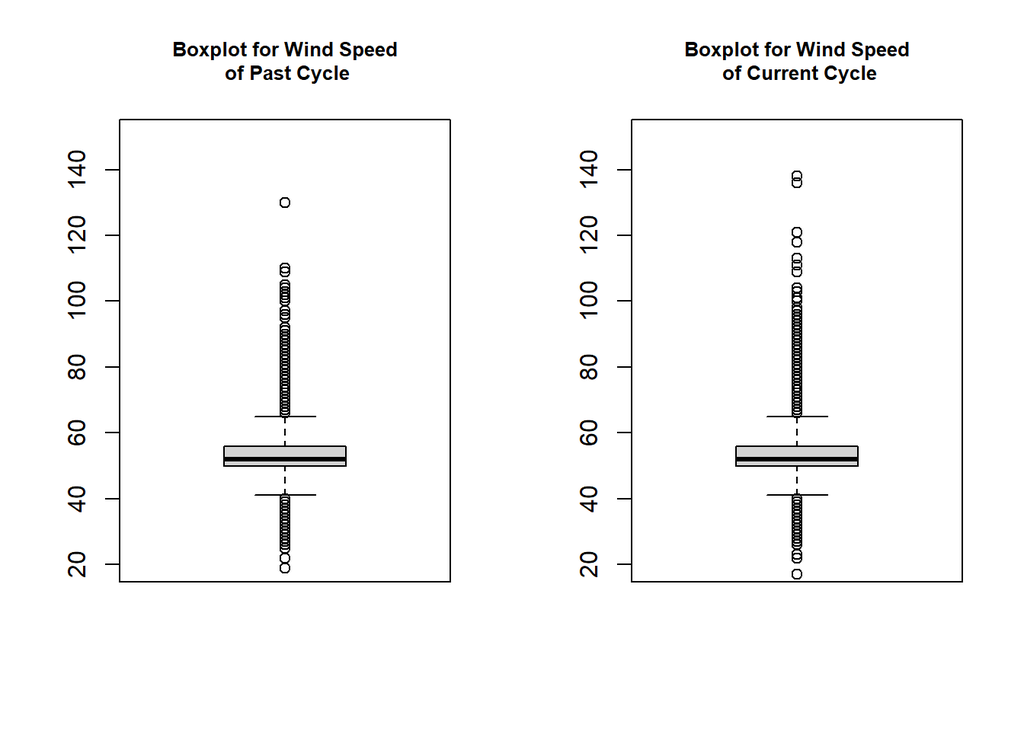

```r
wind.types <- c("High Wind", "Marine High Wind", "Marine Strong Wind", "Marine Thunderstorm Wind", "Strong Wind", "Thunderstorm Wind")
storm.current.wind <- filter(storm.current, EVENT_TYPE %in% wind.types)
storm.past.wind <- filter(storm.past, EVENT_TYPE %in% wind.types)

par(cex.main = 0.8, mfrow = c(1, 2))
# boxplot for wind speed of past and current cycle
boxplot(storm.past.wind$MAGNITUDE, ylim = c(20, 150), main = "Boxplot for Wind Speed\n of Past Cycle")
boxplot(storm.current.wind$MAGNITUDE, ylim = c(20, 150), main = "Boxplot for Wind Speed\n of Current Cycle")
```

From the box plots above, it is noted that both box plots generate similar minimum value, 1st quartile, median, 3rd quartile, and maximum value, the current cycle has more outliers. The current cycle has more records with wind speed larger than 100, and the box plot for past cycle shows that in the past cycle, wind speed varied less and was more concentrated.

While the outliers vary a lot over range, below outlines a closer look for the box plot data points.

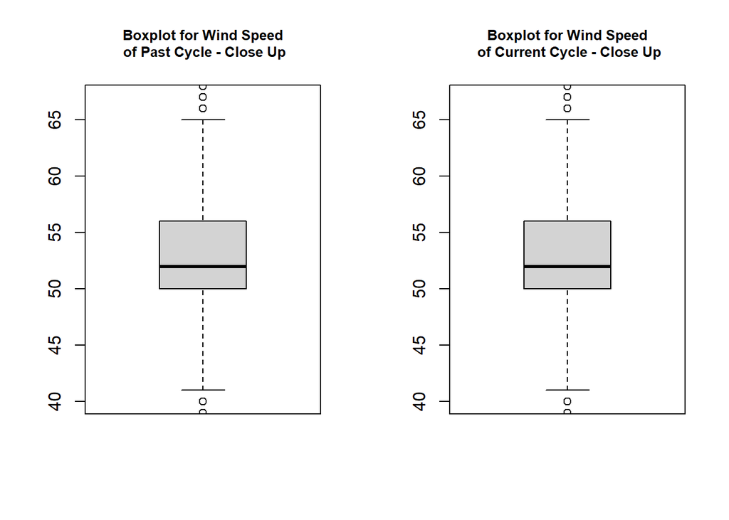

```r
par(cex.main = 0.8, mfrow = c(1, 2))
# boxplot for wind speed of past and current cycle - close up
boxplot(storm.past.wind$MAGNITUDE, ylim = c(40, 67), main = "Boxplot for Wind Speed\n of Past Cycle - Close Up")
boxplot(storm.current.wind$MAGNITUDE, ylim = c(40, 67), main = "Boxplot for Wind Speed\n of Current Cycle - Close Up")
```

By taking a closer look, it is noted that the minimum value, 1st quartile, median, 3rd quartile, and maximum value data points are quite close to each other in both cycles. Both of them have a median around 52. This implicates that although the wind speed for the current cycle is more scattered out, the distribution of wind speed is still similar to the past cycle.

##### Q2d: Has the hail size changed throughout the years?

For hails and marine hails, the magnitude field measures the hail size (in inches to the hundredth). To understand if the hail size has increased or decreased throughout the years, below outlines a comparison of the hail size distributions.

```r
# define a function for calculation of basic statistics
basic.statistics <- function(x) {
  c(minimum = min(x),
    median = median(x),
    mean = mean(x),
    maximum = max(x),
    stddev = sd(x))
}

hail.types <- c("Hail", "Marine Hail")
storm.past.hail <- filter(storm.past, EVENT_TYPE %in% hail.types)
storm.current.hail <- filter(storm.current, EVENT_TYPE %in% hail.types)

# get hail statistics
hail.past.stats <- basic.statistics(storm.past.hail$MAGNITUDE) %>% round(3)
hail.current.stats <- basic.statistics(storm.current.hail$MAGNITUDE) %>% round(3)

# create a data frame for easier examination
data.frame(hail.past.stats, hail.current.stats)
```

```
##         hail.past.stats hail.current.stats
## minimum           0.250              0.250
## median            1.000              1.000
## mean              1.173              1.256
## maximum           5.000              6.000
## stddev            0.483              0.520
```

From the above data frame, it is noted that there is a slight increase in hail size in the current cycle. Although both cycles have the same minimum and median size, since the maximum size increased in the current cycle, the mean also increased by around 7 percent (i.e. (1.256 - 1.173) / 1.173 = 0.07). There is also a slight increase in the standard deviation.

## III. Prediction using long term time series data

##### Q3a: Can we predict the tornado width with tornado length for the next 20 tornadoes using previous data?

```r
# check number of tornado length / width values in the consolidated data set
sum(!is.na(storm.consolidated$TOR_LENGTH))
```

```
## [1] 17513
```

```r
sum(!is.na(storm.consolidated$TOR_WIDTH))
```

```
## [1] 17513
```

From the above result, it seems that the data is quite sufficient, and a training model can be built. By inspection, it is noted that the TOR_LENGTH and TOR_WIDTH values are recorded together, therefore, if one of them has value, the other one would also have value.

```r
# load caret
library(caret)
# drop the na values first, only need to do this one either TOR_LENGTH or TOR_WIDTH
torn.train <- storm.consolidated %>% drop_na(TOR_LENGTH)

# define train control parameters
ctrl <- trainControl(method = 'repeatedcv',
                     repeats = 5)

# define parameters to be used for linear model
torn.lmtrain <- train(TOR_LENGTH ~ TOR_WIDTH,
                           data = torn.train,
                           method = "lm",
                           trControl = ctrl)
torn.lmtrain
```

```
## Linear Regression
##
## 17513 samples
##     1 predictor
##
## No pre-processing
## Resampling: Cross-Validated (10 fold, repeated 5 times)
## Summary of sample sizes: 15762, 15763, 15762, 15762, 15762, 15762, ...
## Resampling results:
##
##   RMSE      Rsquared   MAE
##   3.583192  0.2921491  2.336781
##
## Tuning parameter 'intercept' was held constant at a value of TRUE
```

```r
torn.preds <- predict(torn.lmtrain)
head(torn.preds, 20) %>% round(2)
```

```
##     1     2     3     4     5     6     7     8     9    10    11    12    13
##  2.25  2.25  2.06  2.83  1.90  2.19  1.75  2.45  4.00 10.09 10.09  2.45  3.73
##    14    15    16    17    18    19    20
##  2.45  2.45  2.06  2.06  3.22  1.87  2.45
```

Another training model constructed with k-Nearest Neighbors is illustrated below.

```r
# define train control parameters
ctrl <- trainControl(method = 'repeatedcv',
                     repeats = 5)

# define parameters to be used for linear model
torn.knnfit <- train(TOR_WIDTH ~ TOR_LENGTH ,
                           data = torn.train,
                           method = "knn",
                           trControl = ctrl)
torn.knnfit
```

```
## k-Nearest Neighbors
##
## 17513 samples
##     1 predictor
##
## No pre-processing
## Resampling: Cross-Validated (10 fold, repeated 5 times)
## Summary of sample sizes: 15762, 15762, 15761, 15764, 15761, 15761, ...
## Resampling results across tuning parameters:
##
##   k  RMSE      Rsquared   MAE
##   5  264.7876  0.2254318  144.9430
##   7  260.3439  0.2438890  143.5472
##   9  257.5687  0.2556710  142.6767
##
## RMSE was used to select the optimal model using the smallest value.
## The final value used for the model was k = 9.
```

```r
torn.preds <- predict(torn.knnfit)
head(torn.preds, 20) %>% round(2)
```

```
##  [1] 143.64  90.29  96.88  82.79  50.09 179.08  46.55  46.55 317.38 569.44
## [11] 449.70  51.82 279.18 581.82 609.64 241.67 133.79 109.70  64.58 179.61
```

From the above result, it is noted that KNN also did not do a good job, though it could be because of the poor explainability of tornado width. The model also had poor R-squared, RMSE, and MAE values.